# **Project Task: Week 1:**

# **Deep Neural Network [Original Datasets]**

```python
x_train_DNN_ORG, x_test_DNN_ORG, y_train_DNN_ORG, y_test_DNN_ORG = train_test_split(X_ORG, y, test_size = 0.30, random_state = 21)
print(x_train_DNN_ORG.shape)
print(x_test_DNN_ORG.shape)
print(y_train_DNN_ORG.shape)
print(y_test_DNN_ORG.shape)
```

```
(560, 20531)
(241, 20531)
(560,)
(241,)
```

**Modeling**

```python
import tensorflow as tf
from tensorflow.keras.models import Sequential
from tensorflow.keras.layers import Dense

model_DNN_ORG = Sequential()
model_DNN_ORG.add(tf.keras.layers.BatchNormalization(input_shape=(20531,)))
model_DNN_ORG.add(tf.keras.layers.Dense(20531))
```

**Model - 1st Hidden Layer**

```python
model_DNN_ORG.add(tf.keras.layers.Dense(1000, activation = 'tanh'))
model_DNN_ORG.add(tf.keras.layers.BatchNormalization())
model_DNN_ORG.add(tf.keras.layers.Dropout(0.03))
tf.random.set_seed(10)
```

**Model - 2nd Hidden Layer**

```python
model_DNN_ORG.add(tf.keras.layers.Dense(500))
model_DNN_ORG.add(tf.keras.layers.LeakyReLU())
model_DNN_ORG.add(tf.keras.layers.BatchNormalization())
model_DNN_ORG.add(tf.keras.layers.Dropout(0.01))
tf.random.set_seed(10)
```

**Model - 3rd Hidden Layer**

```python
model_DNN_ORG.add(tf.keras.layers.Dense(250, activation = 'softmax'))
```

**Model - Output Layer**

```python
model_DNN_ORG.add(tf.keras.layers.Dense(5))
```

**Model - Compile**

```python
opt = tf.keras.optimizers.Adam(learning_rate=0.001)
model_DNN_ORG.compile(optimizer=opt, loss='categorical_crossentropy')
```

**Fit & Train the Model**

```python
y_train_DNN_ORG = tf.keras.utils.to_categorical(y_train_DNN_ORG, 5)
y_test_DNN_ORG = tf.keras.utils.to_categorical(y_test_DNN_ORG, 5)

model_DNN_ORG.fit(x_train_DNN_ORG, y_train_DNN_ORG, epochs=10, batch_size=1000, validation_data=(x_test_DNN_ORG, y_test_DNN_ORG))
```

```
<tensorflow.python.keras.callbacks.History at 0x20f59e57700>
```

```python
model_DNN_ORG.summary()
```

```
Model: "sequential"
_________________________________________________________________
Layer (type)                 Output Shape              Param #
=================================================================
batch_normalization (BatchNo (None, 20531)             82124
_________________________________________________________________
dense (Dense)                (None, 20531)             421542492
_________________________________________________________________
dense_1 (Dense)              (None, 1000)              20532000
_________________________________________________________________
batch_normalization_1 (Batch (None, 1000)              4000
_________________________________________________________________
dropout (Dropout)            (None, 1000)              0
_________________________________________________________________
dense_2 (Dense)              (None, 500)               500500
_________________________________________________________________
leaky_re_lu (LeakyReLU)      (None, 500)               0
_________________________________________________________________
batch_normalization_2 (Batch (None, 500)               2000
_________________________________________________________________
dropout_1 (Dropout)          (None, 500)               0
_________________________________________________________________
dense_3 (Dense)              (None, 250)               125250
_________________________________________________________________
dense_4 (Dense)              (None, 5)                 1255
=================================================================
Total params: 442,789,621
Trainable params: 442,745,559
Non-trainable params: 44,062
_________________________________________________________________
```

**Evaluating the accuracy of the model**

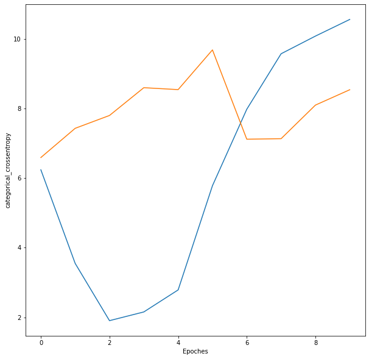

```python
plt.figure(figsize=(10,10))
plt.xlabel('Epoches')

plt.ylabel('categorical_crossentropy')

plt.plot(model_DNN_ORG.history.history['loss'][:])
plt.plot(model_DNN_ORG.history.history['val_loss'][:])
plt.show()
```

```python
y_test_pred_DNN_ORG = model_DNN_ORG.predict(x_test_DNN_ORG)
```

```python
y_test_DNN_ORG_ARG = np.argmax(y_test_DNN_ORG,axis=1)
y_test_pred_DNN_ORG_ARG = np.argmax(model_DNN_ORG.predict(x_test_DNN_ORG),axis=1)

print("Testing Accuracy :", accuracy_score(y_test_DNN_ORG_ARG, y_test_pred_DNN_ORG_ARG).round(4)*100,'%')
```

```
Testing Accuracy : 34.849999999999994 %
```

```python
y_train_DNN_ORG_ARG = np.argmax(y_train_DNN_ORG,axis=1)
y_train_pred_DNN_ORG_ARG = np.argmax(model_DNN_ORG.predict(x_train_DNN_ORG),axis=1)

print("Training Accuracy :", accuracy_score(y_train_DNN_ORG_ARG, y_train_pred_DNN_ORG_ARG).round(4)*100,'%')
```

```
Training Accuracy : 34.29 %
```

```python
print(classification_report(y_test_DNN_ORG_ARG, y_test_pred_DNN_ORG_ARG))
```

```
              precision    recall  f1-score   support

           0       0.41      0.76      0.53        99
           1       0.20      0.41      0.27        22
           2       0.00      0.00      0.00        40
           3       0.00      0.00      0.00        44
           4       0.00      0.00      0.00        36

    accuracy                           0.35       241
   macro avg       0.12      0.23      0.16       241
weighted avg       0.18      0.35      0.24       241
```

```python
print(classification_report(y_train_DNN_ORG_ARG, y_train_pred_DNN_ORG_ARG))
```

```
              precision    recall  f1-score   support

           0       0.38      0.85      0.53       201
           1       0.26      0.39      0.31        56
           2       0.00      0.00      0.00       106
           3       0.00      0.00      0.00        97
           4       0.00      0.00      0.00       100

    accuracy                           0.34       560
   macro avg       0.13      0.25      0.17       560
weighted avg       0.16      0.34      0.22       560
```

```python
y_test_pred_DNN_ROC_ORG = model_DNN_ORG.predict_proba(x_test_DNN_ORG)
print("roc_auc_score: ",roc_auc_score(y_test_DNN_ORG, y_test_pred_DNN_ROC_ORG, multi_class= "ovr"))
```

```
WARNING:tensorflow:Network returning invalid probability values. The last layer might not normalize predictions into probabilities (like softmax or sigmoid would).
roc_auc_score:  0.40319477524887476
```

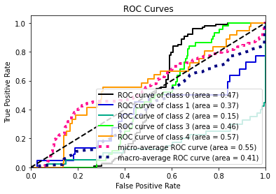

```python
skplt.metrics.plot_roc_curve(y_test_DNN_ORG.argmax(axis=1), y_test_pred_DNN_ROC_ORG)
plt.show()
```

# **Deep Neural Network [Dimensionality Reduction Datasets]**

```python
x_train_DNN_TSNE, x_test_DNN_TSNE, y_train_DNN_TSNE, y_test_DNN_TSNE = train_test_split(X_TSNE, y, test_size = 0.30, random_state = 21)
print(x_train_DNN_TSNE.shape)
print(x_test_DNN_TSNE.shape)
print(y_train_DNN_TSNE.shape)
print(y_test_DNN_TSNE.shape)
```

```
(560, 2)
(241, 2)
(560,)
(241,)
```

**Modeling**

```python
model_DNN_TSNE = Sequential()
model_DNN_TSNE.add(tf.keras.layers.BatchNormalization(input_shape=(2,)))
model_DNN_TSNE.add(tf.keras.layers.Dense(2))
```

**Model - 1st Hidden Layer**

```python
model_DNN_TSNE.add(tf.keras.layers.Dense(10, activation = 'tanh'))
model_DNN_TSNE.add(tf.keras.layers.BatchNormalization())
model_DNN_TSNE.add(tf.keras.layers.Dropout(0.03))
tf.random.set_seed(10)
```

**Model - 2nd Hidden Layer**

```python
model_DNN_TSNE.add(tf.keras.layers.Dense(8))
model_DNN_TSNE.add(tf.keras.layers.LeakyReLU())
model_DNN_TSNE.add(tf.keras.layers.BatchNormalization())
model_DNN_TSNE.add(tf.keras.layers.Dropout(0.01))
tf.random.set_seed(10)
```

**Model - 3rd Hidden Layer**

```python
model_DNN_TSNE.add(tf.keras.layers.Dense(6, activation = 'softmax'))
```

**Model - Output Layer**

```python
model_DNN_TSNE.add(tf.keras.layers.Dense(5))
```

**Model - Compile**

```python
opt = tf.keras.optimizers.Adam(learning_rate=0.001)
model_DNN_TSNE.compile(optimizer=opt, loss='categorical_crossentropy')
```

**Fit & Train the Model**

```python
y_train_DNN_TSNE = tf.keras.utils.to_categorical(y_train_DNN_TSNE, 5)
y_test_DNN_TSNE = tf.keras.utils.to_categorical(y_test_DNN_TSNE, 5)

model_DNN_TSNE.fit(x_train_DNN_TSNE, y_train_DNN_TSNE, epochs=50, batch_size=100, validation_data=(x_test_DNN_TSNE, y_test_DNN_TSNE))
```

```
<tensorflow.python.keras.callbacks.History at 0x20f5a372e50>
```

```python
model_DNN_TSNE.summary()
```

```
Model: "sequential_1"
_________________________________________________________________
Layer (type)                 Output Shape              Param #
=================================================================
batch_normalization_3 (Batch (None, 2)                 8
_________________________________________________________________
dense_5 (Dense)              (None, 2)                 6
_________________________________________________________________
dense_6 (Dense)              (None, 10)                30
_________________________________________________________________
batch_normalization_4 (Batch (None, 10)                40
_________________________________________________________________
dropout_2 (Dropout)          (None, 10)                0
_________________________________________________________________
dense_7 (Dense)              (None, 8)                 88
_________________________________________________________________
leaky_re_lu_1 (LeakyReLU)    (None, 8)                 0
_________________________________________________________________
batch_normalization_5 (Batch (None, 8)                 32
_________________________________________________________________
dropout_3 (Dropout)          (None, 8)                 0
_________________________________________________________________
dense_8 (Dense)              (None, 6)                 54
_________________________________________________________________
dense_9 (Dense)              (None, 5)                 35
=================================================================
Total params: 293
Trainable params: 253
Non-trainable params: 40
_________________________________________________________________
```

**Evaluating the accuracy of the model**

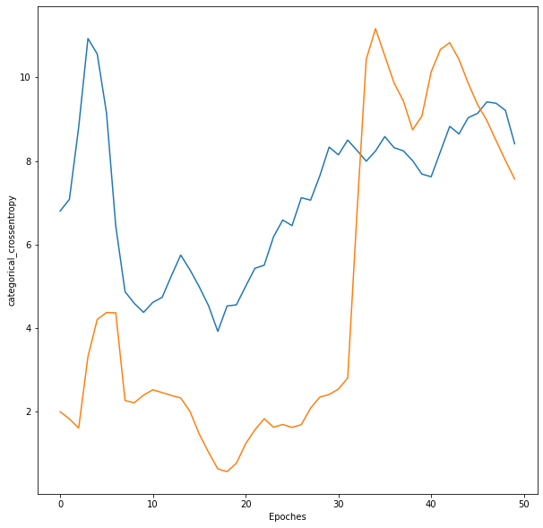

```python
plt.figure(figsize=(10,10))
plt.xlabel('Epoches')

plt.ylabel('categorical_crossentropy')

plt.plot(model_DNN_TSNE.history.history['loss'][:])
plt.plot(model_DNN_TSNE.history.history['val_loss'][:])
plt.show()
```

```python
y_test_pred_DNN_TSNE = model_DNN_TSNE.predict(x_test_DNN_TSNE)
```

```python
y_test_DNN_TSNE_ARG = np.argmax(y_test_DNN_TSNE,axis=1)
y_test_pred_DNN_TSNE_ARG = np.argmax(model_DNN_TSNE.predict(x_test_DNN_TSNE),axis=1)

print("Testing Accuracy :", accuracy_score(y_test_DNN_TSNE_ARG, y_test_pred_DNN_TSNE_ARG).round(4)*100,'%')
```

```
Testing Accuracy : 57.68 %
```

```python
y_train_DNN_TSNE_ARG = np.argmax(y_train_DNN_TSNE,axis=1)
y_train_pred_DNN_TSNE_ARG = np.argmax(model_DNN_TSNE.predict(x_train_DNN_TSNE),axis=1)

print("Training Accuracy :", accuracy_score(y_train_DNN_TSNE_ARG, y_train_pred_DNN_TSNE_ARG).round(4)*100,'%')
```

```
Training Accuracy : 54.82 %
```

```python
print(classification_report(y_test_DNN_TSNE_ARG, y_test_pred_DNN_TSNE_ARG))
```

```
              precision    recall  f1-score   support

           0       0.49      1.00      0.66        99
           1       0.00      0.00      0.00        22
           2       1.00      1.00      1.00        40
           3       0.00      0.00      0.00        44
           4       0.00      0.00      0.00        36

    accuracy                           0.58       241
   macro avg       0.30      0.40      0.33       241
weighted avg       0.37      0.58      0.44       241
```

```python
print(classification_report(y_train_DNN_TSNE_ARG, y_train_pred_DNN_TSNE_ARG))
```

```
              precision    recall  f1-score   support

           0       0.44      1.00      0.61       201
           1       0.00      0.00      0.00        56
           2       1.00      1.00      1.00       106
           3       0.00      0.00      0.00        97
           4       0.00      0.00      0.00       100

    accuracy                           0.55       560
   macro avg       0.29      0.40      0.32       560
weighted avg       0.35      0.55      0.41       560
```

```python
y_test_pred_DNN_ROC_TSNE = model_DNN_TSNE.predict_proba(x_test_DNN_TSNE)
print("roc_auc_score: ",roc_auc_score(y_test_DNN_TSNE, y_test_pred_DNN_ROC_TSNE, multi_class= "ovr"))
```

```
WARNING:tensorflow:Network returning invalid probability values. The last layer might not normalize predictions into probabilities (like softmax or sigmoid would).
roc_auc_score:  0.5681236650729403
```

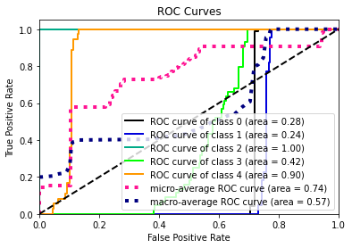

```python
skplt.metrics.plot_roc_curve(y_test_DNN_TSNE.argmax(axis=1), y_test_pred_DNN_ROC_TSNE)
plt.show()
```

**Observation**